# 3.16. Refer to Solution concentration Problem 3.15.

## a. Prepare a scatter plot of the data. What transformation of Y might you try, using the prototype patterns in Figure 3.15 to achieve constant variance and linearity?

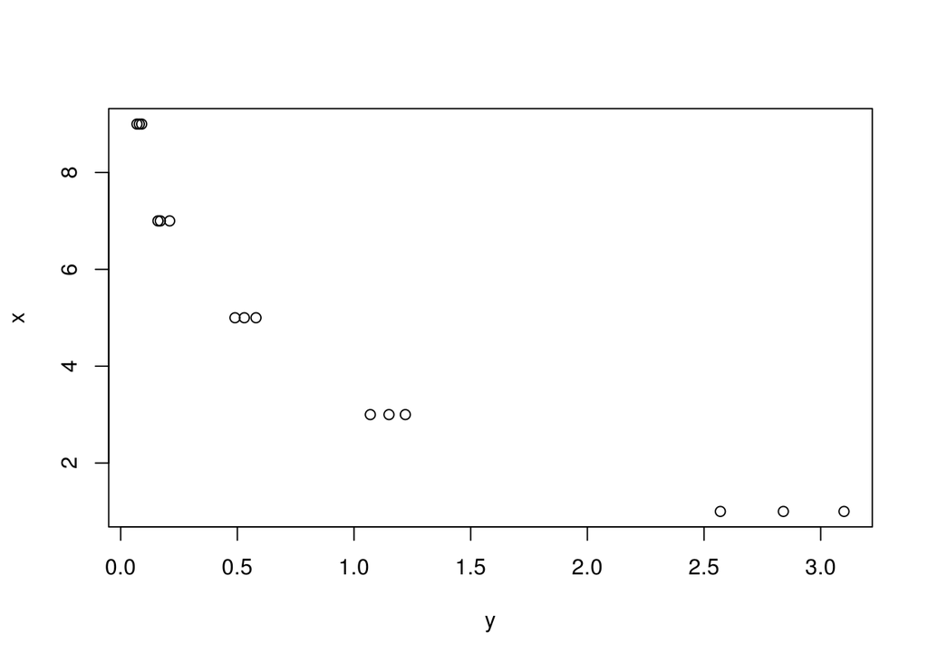

```r
plot(chemist)
```

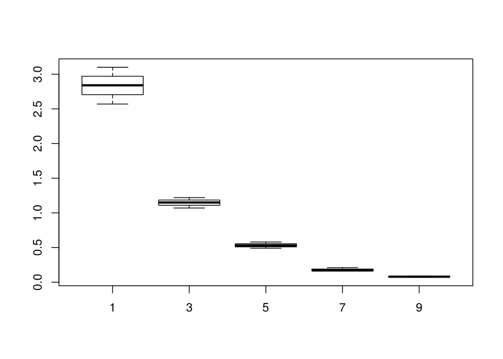

```r
plot(factor(chemist$x),chemist$y)
```

```r
## Scatter plot suggests that the data is clustered around the mean of Y for constant X, so log is a effective remedy to expand the data
```

- We can use log transformation of data ~ with the observations from the above plots

## b. Use the Box-Cox procedure and standardization (3.36) to find an appropriate power transformation. Evaluate SSE for A = -.2, -.1,0, .1, .2. What transformation of Y is suggested?

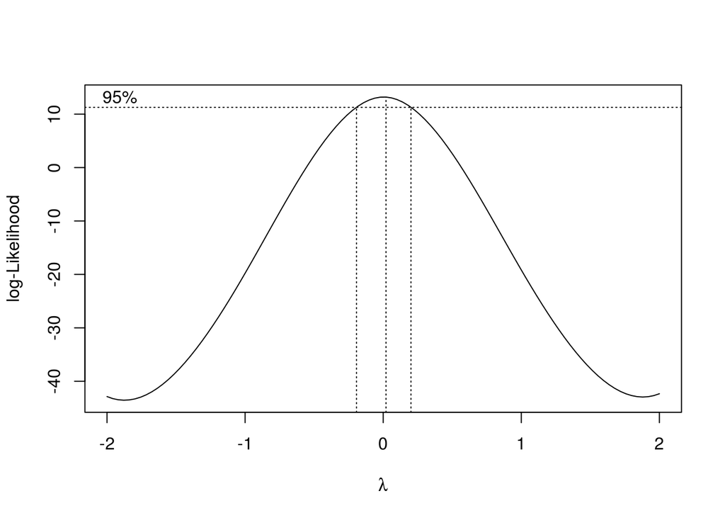

```r
library(MASS)
boxcox(cmodel,lambda = seq(-2,2,1))
```

- From the above plot ~ boxcox suggest that λ is near to zero, this suggests that we should use log transformtions for we know that Y^λ = log(Y) if λ =0

## c. Use the transformation Y’ = 10gIO Y and obtain the estimated linear regression function for the transformed data.

```r
logmodel=lm(log10(chemist$y)~chemist$x)
logmodel
```

```
##
## Call:
## lm(formula = log10(chemist$y) ~ chemist$x)
##
## Coefficients:
## (Intercept)    chemist$x
##      0.6549      -0.1954
```

## d. Plot the estimated regression line and the transformed data Does the regression line appear to be a good fit to the transformed data?

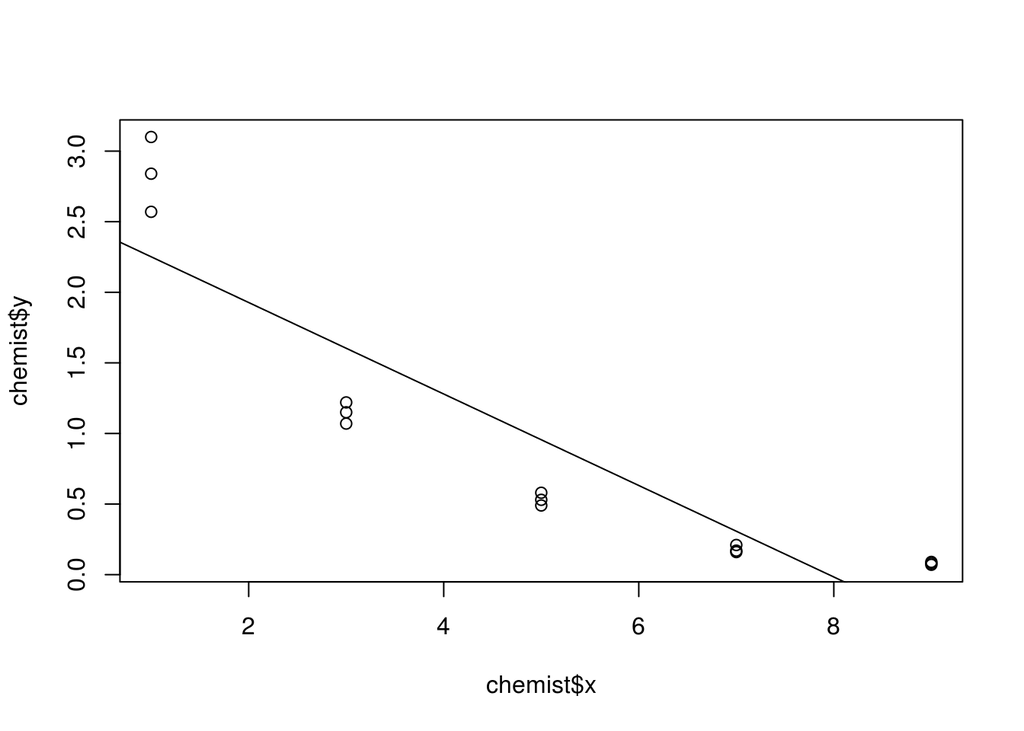

```r
# for normal values
plot(chemist$x,chemist$y)
abline(cmodel)
```

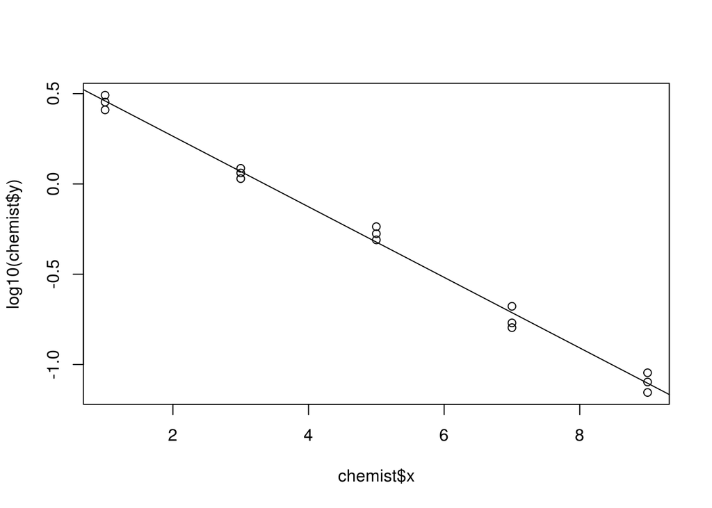

```r
# for transformed values

plot(chemist$x,log10(chemist$y))
abline(logmodel)
```

- The line appears to be a good fit as it passes through all the distributions of Y

## e. Obtain,the residuals and plot them against the fitted values. Also prepare a normal probability plot. What do your plots show?

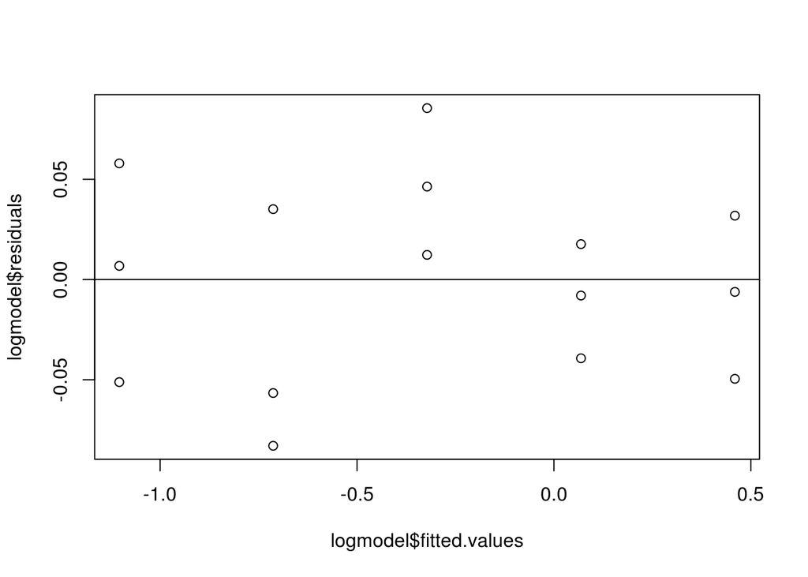

```r
plot(logmodel$fitted.values,logmodel$residuals)
abline(h=0)
```

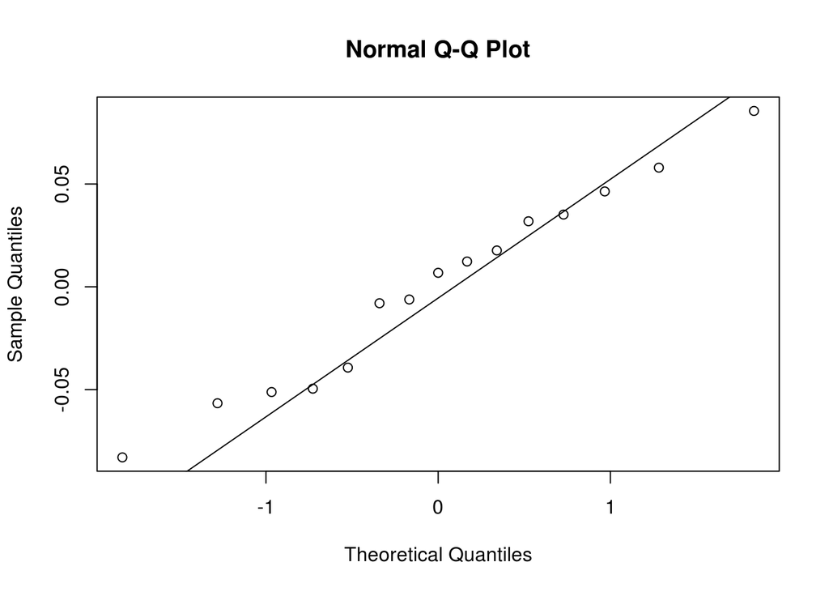

```r
# residual seems to be split equally on either side of Y=0 this is sign of normal distribution, thus indicating a constant variance

qqnorm(logmodel$residuals)
qqline(logmodel$residuals)
```

```r
# qqplot indicate that the residuals are normally distributed which is also one of our assumptions
```

## f. Express the estimated regression function in the original units.

log<sub>10</sub>(Y) = 0.6549 - 0.1954X